# R Notebook

week 11 Based on the mass and year, create a decision tree model of your meteorites data which predicts whether a meteorite was seen falling, or was discovered after its impact (fell/found).

First, you want to convert any character column to a factor. Next (and most importantly) split your dataset into training and testing datasets. Then create a decision tree with rpart and plot it using rpart.plot. Finally, test and add your predictions to your data, and create a confusion matrix.

```r
library(rpart)
library(rpart.plot)
library(dplyr)
```

```r
clean_mete %>% head()
```

| id | name | mass_g | fall | year | latitude | longitude |
| --- | --- | --- | --- | --- | --- | --- |
| 5295 | Castrovillari | 15000 | Fell | 1583 | 39.80000 | 16.20000 |
| 16745 | Morito | 10100000 | Found | 1600 | 27.05000 | -105.43333 |
| 12069 | Jalandhar | 1967 | Fell | 1621 | 31.00000 | 75.00000 |
| 23732 | Stretchleigh | 10400 | Fell | 1623 | 50.38333 | -3.95000 |
| 11855 | Hatford | 29000 | Fell | 1628 | 51.65000 | -1.51667 |
| 16692 | Minamino | 1040 | Fell | 1632 | 35.07833 | 136.93333 |

```r
mete_tree <- clean_mete %>% select(mass_g, year,fall) %>%
  mutate(fall = factor(fall, levels = c("Found", "Fell"), labels = c("Found", "Fell"))) %>%
   na.omit()
mete_tree
```

| mass_g | year | fall |
| --- | --- | --- |
| 15000.0 | 1583 | Fell |
| 10100000.0 | 1600 | Found |
| 1967.0 | 1621 | Fell |
| 10400.0 | 1623 | Fell |
| 29000.0 | 1628 | Fell |
| 1040.0 | 1632 | Fell |
| 17000.0 | 1637 | Fell |
| 4500.0 | 1671 | Fell |
| 7000.0 | 1715 | Fell |
| 1700.0 | 1716 | Found |

[output cut: 990 more lines]

```r
set.seed(19)

n_data <- nrow(mete_tree)

test_index <- sample(1:n_data, size = n_data*0.2)

# create test set
test  <- slice(mete_tree, test_index)

# create training set
train <- slice(mete_tree, -test_index)
```

```r
test %>%
 janitor::tabyl(fall)
```

```
  fall   n   percent
 Found 818 0.8503119
  Fell 144 0.1496881
```

```r
train %>%
 janitor::tabyl(fall)
```

```
  fall    n   percent
 Found 3256 0.8452752
  Fell  596 0.1547248
```

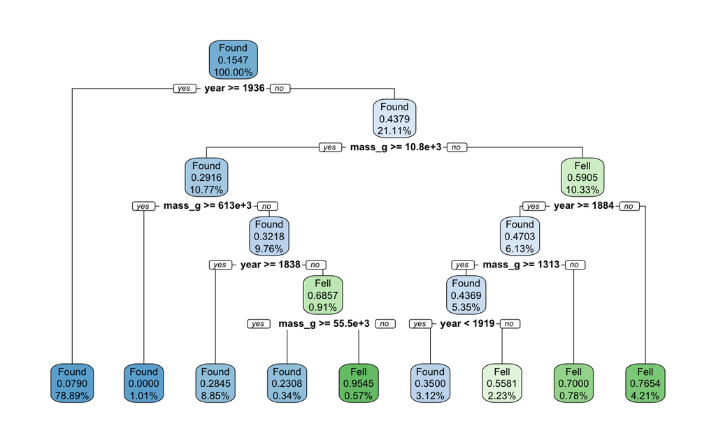

```r
mete_fit <- rpart(
  formula = fall ~ .,
  data = train,
  method = 'class'
)

rpart.plot(mete_fit,
           yesno = 2,
           fallen.leaves = TRUE,
           faclen = 6,
           digits = 4)
```

[output not shown]

```r
library(modelr)

# add the predictions
mete_test_pred <- test %>%
  add_predictions(mete_fit, type = 'class')
```

```r
library(yardstick)
conf_mat <- mete_test_pred %>%
              conf_mat(truth = fall, estimate = pred)

conf_mat
```

```
          Truth
Prediction Found Fell
     Found   799  101
     Fell     19   43
```

```
This model performs quite good, it's mostly correct. 799 true possitive and 43 true negative
with 120 errors.
```

```r
accuracy <- mete_test_pred %>%
 accuracy(truth = fall, estimate = pred)

accuracy
```

| .metric | .estimator | .estimate |
| --- | --- | --- |
| accuracy | binary | 0.8752599 |

```
It's 87.53% correct
```